# ME613 - Análise de Regressão

## Propriedades dos estimadores

## Suposições do modelo de regressão linear simples

Até o momento, apenas suposições sobre esperança, variância e correlação foram feitas.

Desta forma, sabemos que os estimadores são não viesados e sabemos também quão precisos eles são.

No entanto, para construirmos intervalos e confiança, precisamos conhecer a distribuição de probabilidade desses estimadores.

## Suposições do modelo de regressão linear simples

A partir de agora iremos assumir:

1. \(Y_i=\beta_0+\beta_1X_i+\varepsilon_i\quad i=1,2,\ldots,n\)
2. \(\varepsilon_i\) uma v.a. que segue a distribuição **Normal** em que \(E(\varepsilon_i)=0\) e \(Var(\varepsilon_i)=\sigma^2\) desconhecida, para \(i=1,2,\ldots,n\).
3. \(\varepsilon_i\) e \(\varepsilon_j\) são não-correlacionados para \(i\neq j\), portanto \(Cov(\varepsilon_i,\varepsilon_j)=0\) para \(i\neq j\).

> A suposição 3 implica em independência entre as observações \(i\) e \(j\), \(i\neq j\), no caso de normalidade. Desta maneira, utilizando as suposições 2 e 3, temos que \(\varepsilon_i\)’s são iid.

## Propriedades de \(Y_i\)

Já tínhamos visto que valor esperado para a resposta \(Y_i\), fixando \(X_i\) é:

\[ E(Y_i)=\beta_0+\beta_1X_i \]

> E a variância para a resposta \(Y_i\), fixando \(X_i\) é:

\[ Var(Y_i)=\sigma^2 \]

> Utilizando a suposição 2, temos que a resposta \(Y_i\) vem de uma **distribuição Normal** com \(E(Y_i)=\beta_0+\beta_1X_i\) (**função de regressão**) e \(Var(Y_i)=\sigma^2\).

> A resposta, \(Y_i\) está acima ou abaixo da função de regressão por um termo de erro \(\varepsilon_i\) que segue a **distribuição Normal**.

## Propriedades de \(Y_i\)

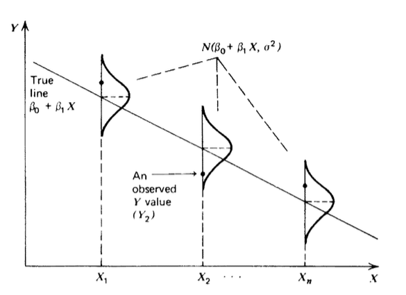

## Distribuição amostral de \(\hat{\beta}_1\)

\[\hat{\beta}_1=\frac{\sum_{i=1}^n(X_i-\bar{X})Y_i}{\sum_{i=1}^n(X_i-\bar{X})^2}\]

> Suponha que tenhamos \(X_i\)’s fixos, mas que observamos \(Y_i\)’s várias vezes. A cada vez \(\hat{\beta}_1\) será diferente.

> \(\hat{\beta}_1\) muda conforme mudamos nossa amostra. Desta forma, devemos estudar sua distribuição amostral.

> A distribuição amostral de \(\hat{\beta}_1\) dependerá das suposições que fizermos para o modelo de regressão.

## Distribuição amostral de \(\hat{\beta}_1\)

Vimos que, sem suposição de distribuição de probabilidade, apenas com o momentos definidos, temos que:

\[E(\hat{\beta}_1)=\beta_1\]

\[Var(\hat{\beta}_1)=\frac{\sigma^2}{\sum_{i=1}^n(X_i-\bar{X})^2}\]

> Se supomos que \(\varepsilon_i\underset{iid}{\sim}\mathcal{N}(0,\sigma^2)\), temos:

\[\hat{\beta}_1\sim\mathcal{N}\left(\beta_1,\frac{\sigma^2}{\sum_{i=1}^n(X_i-\bar{X})^2}\right)\]

## Distribuição amostral de \(\hat{\beta}_1\)

Padronizando, temos que:

\[\frac{\hat{\beta}_1-\beta_1}{\sqrt{Var(\hat{\beta}_1)}}\sim\mathcal{N}(0,1)\]

> Problema: \(Var(\hat{\beta}_1)\) depende de \(\sigma^2\), portanto é desconhecida.

## Relembrando distribuição \(t\)-Student

Sejam \(Z\sim\mathcal{N}(0,1)\) e \(V\sim\chi^2_{\nu}\), **independentes**, então

\[T=\frac{Z}{\sqrt{V/\nu}}\sim t_{\nu}\]

> **Mostre\(^1\)** que

\[\frac{\hat{\beta}_1-\beta_1}{\sqrt{\widehat{Var(\hat{\beta}_1)}}}\sim\mathcal{t}_{n-2}\]

em que \[\widehat{Var(\hat{\beta}_1)}=\frac{s^2}{\sum_{i=1}^n(X_i-\bar{X})^2}\quad \mbox{e} \quad s^2=\frac{\sum_{i=1}^n(Y_i-\hat{Y}_i)^2}{n-2}\]

## Intervalos de confiança para os estimadores

## Intervalo de confiança para \(\beta_1\)

\[\hat{\beta}_1=\frac{\sum_{i=1}^n(X_i-\bar{X})Y_i}{\sum_{i=1}^n(X_i-\bar{X})^2}\]

\[\widehat{Var(\hat{\beta}_1)}=\frac{s^2}{\sum_{i=1}^n(X_i-\bar{X})^2}\]

Um intervalo de \(100(1-\alpha)\%\) de confiança para \(\beta_1\) é dado por:

\[\begin{eqnarray} IC(\beta_1, 1-\alpha) &=& \left[\hat{\beta}_1 -t_{n-2,\alpha/2}\sqrt{\frac{s^2}{\sum_{i=1}^n(X_i-\bar{X})^2}};\right.\\ & &\left. \hat{\beta}_1 +t_{n-2,\alpha/2}\sqrt{\frac{s^2}{\sum_{i=1}^n(X_i-\bar{X})^2}}\right] \end{eqnarray}\]

## Intervalo de confiança para \(\beta_0\)

Especificamente, para o intercepto, temos que:

\[\hat{\beta}_0=\bar{Y}-\hat{\beta}_1\bar{X}\]

\[\widehat{Var(\hat{\beta}_0)} = s^2\left (\frac{1}{n} + \frac{\bar{X}^2}{\sum_{i=1}^n(X_i-\bar{X})^2} \right)\]

## Intervalo de confiança para \(\beta_0\)

Um intervalo de \(100(1-\alpha)\%\) de confiança para \(\beta_0\) é dado por:

\[\begin{eqnarray} IC(\beta_0, 1-\alpha) &=& \left[\hat{\beta}_0 -t_{n-2,\alpha/2}\sqrt{s^2\left (\frac{1}{n} + \frac{\bar{X}^2}{\sum_{i=1}^n(X_i-\bar{X})^2} \right)};\right.\\ & &\left. \hat{\beta}_0 +t_{n-2,\alpha/2}\sqrt{s^2\left (\frac{1}{n} + \frac{\bar{X}^2}{\sum_{i=1}^n(X_i-\bar{X})^2} \right)}\right] \end{eqnarray}\]

## Como encontrar \(t_{n-2,\alpha/2}\)

\[T\sim t_{n-2}\] \[P(-t_{n-2,\alpha/2} < T < t_{n-2,\alpha/2}) = 1-\alpha\]

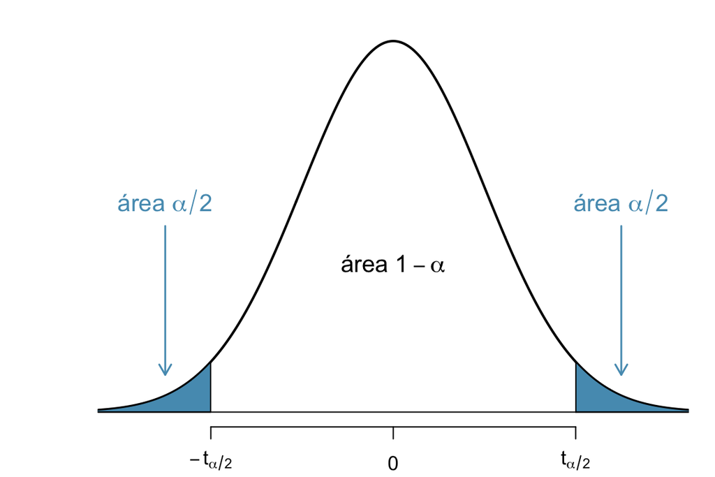

## Distribuição \(t\)-student e Normal Padrão

Para \(n\) grande a distribuição \(t\)-student se aproxima da normal padrão \(N(0,1)\).

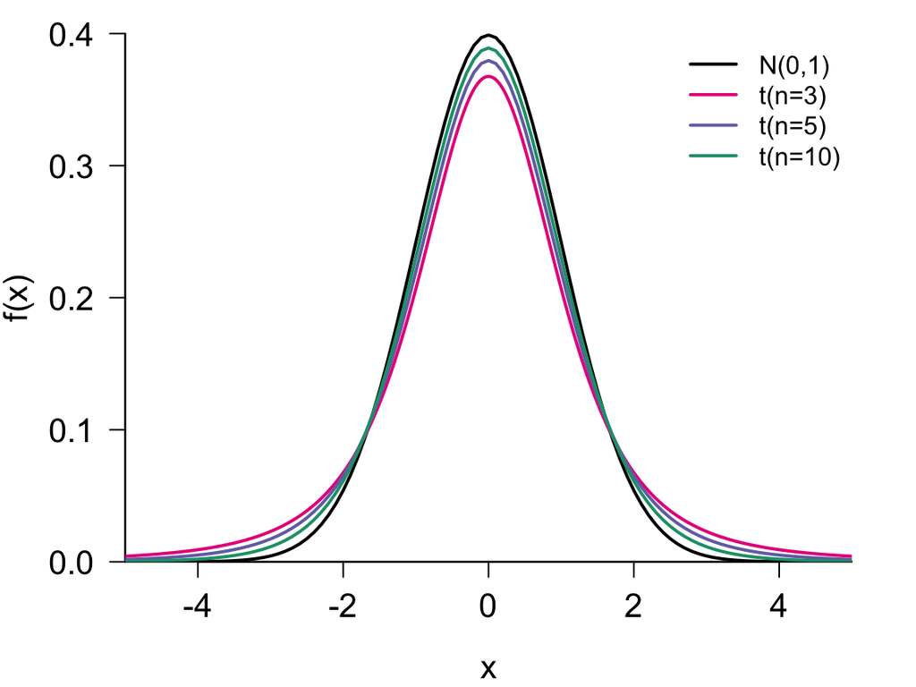

## Teste de Hipóteses

## Revisão: Testes de Hipóteses

- Hipótese nula: \(H_0\)
- Hipótese alternativa: \(H_a\)
- Estatística do teste
- Nível de significância
- Região de rejeição

## Revisão: Testes de Hipóteses

Erros:

- Erro do Tipo I: \(H_0\) é rejeitada quando é verdadeira. A probabilidade do erro tipo I é \(\alpha\) (nível de significância do teste).
- Erro do Tipo II: \(H_0\) não é rejeitada quando \(H_a\) é verdadeira. A probabilidade do erro tipo II é \(\beta\).

| Decisão | \(H_0\) é verdadeira | \(H_a\) é verdadeira |
| --- | --- | --- |
| Aceita \(H_0\) | Correto | Erro Tipo II |
| Rejeita \(H_0\) | Erro Tipo I | Correto |

## Teste de Hipóteses para \(\beta_1\)

- \(H_0\): \(\beta_1=0\)
- \(H_a\): \(\beta_1\neq 0\)

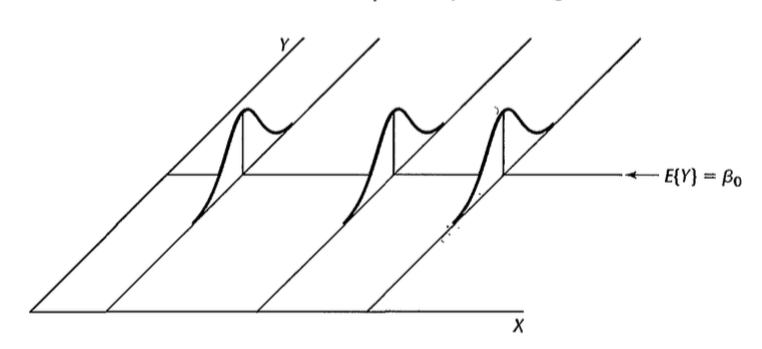

## Teste de Hipóteses para \(\beta_1\)

> Usaremos como estatística do teste nosso estimador: \(\hat{\beta}_1\).

> Se o valor observado, isto é, a estimativa \(\hat{\beta}_1\) estiver longe de 0, temos evidências contra \(H_0\).

> Quão longe?

> Temos que levar em conta a distribuição de probabilidade do estimador \(\hat{\beta}_1\) quando \(H_0\) é verdadeira:

\[\frac{\hat{\beta}_1-\beta_1}{\sqrt{\widehat{Var(\hat{\beta}_1)}}}\overset{H_0:\beta_1=0}{=}\frac{\hat{\beta}_1}{\sqrt{\widehat{Var(\hat{\beta}_1)}}}\overset{H_0:\beta_1=0}{\sim}\mathcal{t}_{n-2}\]

## Exemplo: Empresa Toluca

A empresa Toluca fabrica equipamentos de refrigeração e peças de reposição.

> No passado, uma das peças de reposição era produzida periodicamente em lotes de tamanhos variável.

> Para reduzir os custos, o diretor da empresa queria que se determinasse o tamanho ótimo do lote.

> Para descobrir o tamanho ideal do lote é de extrema importância avaliar a relação entre tamanho do lote de total de horas trabalhadas na produção do mesmo.

> Para tanto, avaliou-se o tamanho do lote e o número de horas para 25 lotes recentemente produzidos.

## Exemplo: Empresa Toluca

\(V1\): tamanho do lote

\(V2\): horas trabalhadas para produzir o lote

10 primeiras observações do conjunto de dados:

```
##     V1  V2
## 1   80 399
## 2   30 121
## 3   50 221
## 4   90 376
## 5   70 361
## 6   60 224
## 7  120 546
## 8   80 352
## 9  100 353
## 10  50 157
```

## Exemplo: Empresa Toluca

\(Y_i\): horas trabalhadas para produzir o lote \(i\)

\(X_i\): tamanho do lote \(i\)

\(Y_i=\beta_0+\beta_1X_i+\varepsilon_i\)

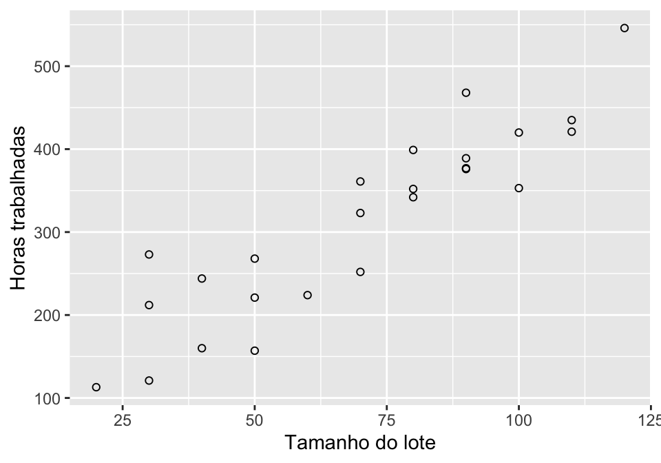

## Exemplo: Empresa Toluca

```
##
## Call:
## lm(formula = V2 ~ V1, data = dados)
##
## Residuals:
##     Min      1Q  Median      3Q     Max
## -83.876 -34.088  -5.982  38.826 103.528
##
## Coefficients:
##             Estimate Std. Error t value Pr(>|t|)
## (Intercept)   62.366     26.177   2.382   0.0259 *
## V1             3.570      0.347  10.290 4.45e-10 ***
## ---
## Signif. codes:  0 '***' 0.001 '**' 0.01 '*' 0.05 '.' 0.1 ' ' 1
##
## Residual standard error: 48.82 on 23 degrees of freedom
## Multiple R-squared:  0.8215, Adjusted R-squared:  0.8138
## F-statistic: 105.9 on 1 and 23 DF,  p-value: 4.449e-10
```

## Exemplo: Empresa Toluca

\(\hat{\beta_1}=3.57\)

\(\hat{\beta_0}=62.37\)

Estimamos que o número médio de horas trabalhadas aumenta em \(3.57\) para cada unidade adicional produzida no lote.

Esta estimativa se aplica a tamanhos de lote utilizados na análise: 20 a 120.

\(\hat{E}(Y|X)=\hat{Y}=62.37+3.57X\).

Desta forma, com a equação acima, podemos estimar o número esperado de horas trabalhadas para qualquer tamanho de lote.

## Exemplo: Empresa Toluca

Por exemplo, segundo o modelo ajustado:

- para um lote de tamanho 30, temos que o número esperado de horas trabalhadas é 169.47.
- para um lote de tamanho 40, temos que o número esperado de horas trabalhadas é 205.17.

Observe que este valores são esperados e que há uma variabilidade ao redor desde valor.

Por exemplo: para lotes de tamanho 30, o valor esperado é 169.47, mas chegamos a observar 121, 212, 273 nos dados.

Para lotes de tamanho 40, o valor esperado é 205.17, mas chegamos a observar 160, 244 nos dados.

## Exemplo: Empresa Toluca

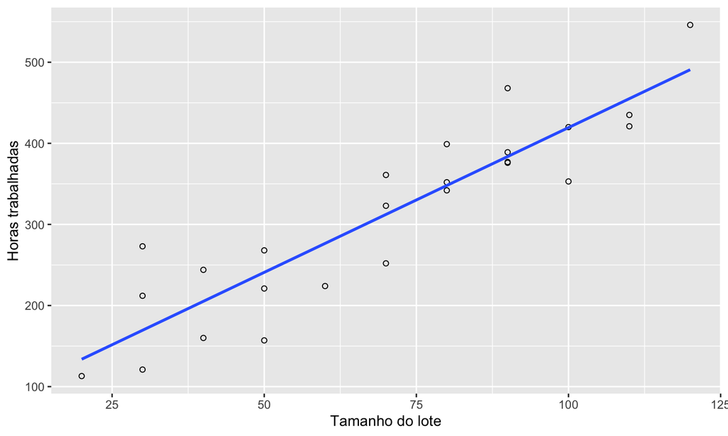

## Predição

## Predição

A função ajustada, \(\hat{Y}_i=\hat{E}(Y\mid X=X_i)\) pode ser usada para obter valores para a variável resposta para qualquer valor da variável preditora.

> É importante distinguir dois problemas diferentes: predição e estimação de valores ajustados.

> Em predição, temos uma nova observação cujo valor da variável preditora é \(X^*\), possivelmente uma observação futura, não utilizada nas estimativas dos parâmetros.

> Queremos saber o valor de \(Y^*\) correspondente, mas que ainda não foi observado.

## Predição

Podemos usar a reta estimada de maneira que uma predição pontual de \(Y^*\), indicada por \(\tilde{Y}^*\) é dada por:

> \[\tilde{Y}^*=\hat{\beta}_0+\hat{\beta}_1X^*_i\]

> Quão precisa é esta estimativa?

\[Var(\tilde{Y}^*\mid X=X^*_i)=\sigma^2+\sigma^2\left( \frac{1}{n}+\frac{(X^*_i-\bar{X})^2}{\sum_{i=1}^n(X_i-\bar{X})^2} \right)\]

> (ver [seção 2.6.3](http://site.ebrary.com/lib/unicamp/reader.action?ppg=52&docID=10867127&tm=1457111302091))

## Exemplo: precificação de diamantes

```r
library(UsingR); data(diamond)
y <- diamond$price; x <- diamond$carat; n <- length(y)
beta1 <- cor(y, x) * sd(y) / sd(x)
beta0 <- mean(y) - beta1 * mean(x)
e <- y - beta0 - beta1 * x
sigma <- sqrt(sum(e^2) / (n-2))
ssx <- sum((x - mean(x))^2)
seBeta0 <- (1 / n + mean(x) ^ 2 / ssx) ^ .5 * sigma
seBeta1 <- sigma / sqrt(ssx)
tBeta0 <- beta0 / seBeta0; tBeta1 <- beta1 / seBeta1
pBeta0 <- 2 * pt(abs(tBeta0), df = n - 2, lower.tail = FALSE)
pBeta1 <- 2 * pt(abs(tBeta1), df = n - 2, lower.tail = FALSE)
coefTable <- rbind(c(beta0, seBeta0, tBeta0, pBeta0), c(beta1, seBeta1, tBeta1, pBeta1))
colnames(coefTable) <- c("Estimate", "Std. Error", "t value", "P(>|t|)")
rownames(coefTable) <- c("(Intercept)", "x")
```

## Exemplo: precificação de diamantes

```r
coefTable
```

```
##              Estimate Std. Error   t value      P(>|t|)
## (Intercept) -259.6259   17.31886 -14.99094 2.523271e-19
## x           3721.0249   81.78588  45.49715 6.751260e-40
```

```r
fit <- lm(y ~ x);
summary(fit)$coefficients
```

```
##              Estimate Std. Error   t value     Pr(>|t|)
## (Intercept) -259.6259   17.31886 -14.99094 2.523271e-19
## x           3721.0249   81.78588  45.49715 6.751260e-40
```

## Exemplo: precificação de diamantes

IC para o intercepto:

```r
sumCoef <- summary(fit)$coefficients
sumCoef[1,1] + c(-1, 1) * qt(.975, df = fit$df) * sumCoef[1, 2]
```

```
## [1] -294.4870 -224.7649
```

Equivalente:

```r
confint(fit)[1,]
```

```
##     2.5 %    97.5 %
## -294.4870 -224.7649
```

## Exemplo: precificação de diamantes

IC para o aumento de preço para 0.1 carat de aumento no tamanho do diamante:

```r
(sumCoef[2,1] + c(-1, 1) * qt(.975, df = fit$df) * sumCoef[2, 2]) / 10
```

```
## [1] 355.6398 388.5651
```

Equivalente:

```r
confint(fit)[2,]/10
```

```
##    2.5 %   97.5 %
## 355.6398 388.5651
```

Com 95% de confiança, estimamos que um aumento de 0.1 carat no tamanho do diamante resulta em um aumento médio entre 355.6 e 388.6 dólares.

## Exemplo: precificação de diamantes

Agora, vamos verificar a precisão quando fazemos predições.

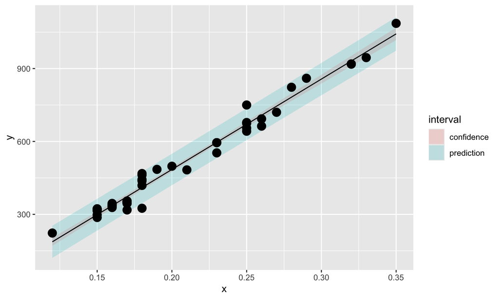

## Discussão

Lembrem que tínhamos dois problemas diferentes: predição e estimação de valores ajustados.

- Em rosa temos o intervalo para a reta estimada (valor esperado).
- Em azul temos o intervalo para predição de valores pontuais.
- Ambos os intervalos têm comprimento variável para diferentes valores de \(X\).
- Ambos os intervalos apresentam menor comprimento perto de \(\bar{X}\).
- A confiança na reta ajustada é maior, portanto seu IC tem menor comprimento
- O intervalo para a predição incorpora a variabilidade dos dados ao redor da reta.

## Exemplo: usando a função `predict` do R

```r
x <- rnorm(15)
y <- x + rnorm(15)
predict(lm(y ~ x))
```

```
##          1          2          3          4          5          6          7
## -0.9543368 -0.5994233 -0.2485210 -0.6166903 -1.2467930 -0.1604254 -1.5488326
##          8          9         10         11         12         13         14
## -0.9185407 -0.6875162  0.4314947 -2.4969231 -1.0438140 -0.1746270 -0.2957539
##         15
## -0.9142725
```

## Exemplo: usando a função `predict` do R

```r
new <- data.frame(x = seq(-3, 3, 0.5))
predict(lm(y ~ x), new, se.fit = TRUE)
```

```
## $fit
##          1          2          3          4          5          6          7
## -3.2657749 -2.8167011 -2.3676274 -1.9185537 -1.4694799 -1.0204062 -0.5713324
##          8          9         10         11         12         13
## -0.1222587  0.3268151  0.7758888  1.2249626  1.6740363  2.1231101
##
## $se.fit
##         1         2         3         4         5         6         7         8
## 1.0086161 0.8407716 0.6765555 0.5194206 0.3782963 0.2786724 0.2710138 0.3612181
##         9        10        11        12        13
## 0.4987469 0.6544146 0.8179292 0.9853923 1.1550877
##
## $df
## [1] 13
##
## $residual.scale
## [1] 1.00812
```

## Exemplo: usando a função `predict` do R

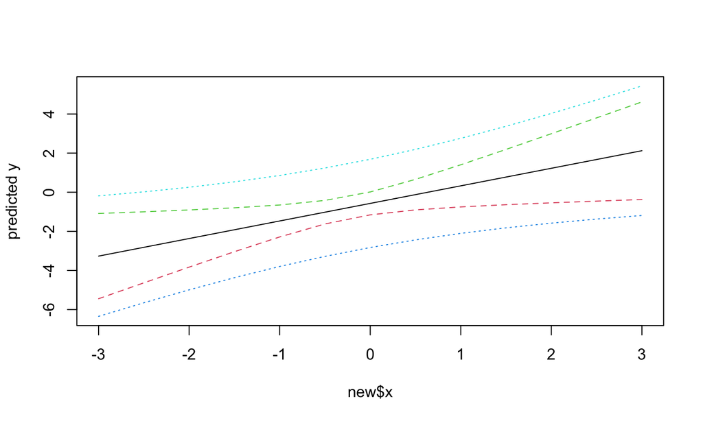

```r
pred.w.plim <- predict(lm(y ~ x), new, interval = "prediction")
pred.w.clim <- predict(lm(y ~ x), new, interval = "confidence")
matplot(new$x, cbind(pred.w.clim, pred.w.plim[,-1]),
        lty = c(1,2,2,3,3), type = "l", ylab = "predicted y")
```

## Leituras sobre suposição de normalidade

- [The Importance of the Normality Assumption in Large Public Health Data Sets](http://rctdesign.org/techreports/arphnonnormality.pdf)
- [The Assumption(s) of Normality](http://www2.psychology.uiowa.edu/faculty/mordkoff/GradStats/part%201/I.07%20normal.pdf)
- [Understanding Regression Assumptions](https://us.sagepub.com/en-us/sam/understanding-regression-assumptions/book3056)

## Leitura

- Applied Linear Statistical Models: 1.8, 2.1-2.9.
- Caffo - [Regression Models for Data Science in R](https://leanpub.com/regmods): Regression Inference.
- Draper & Smith - [Applied Regression Analysis](http://onlinelibrary.wiley.com/book/10.1002/9781118625590): 1.4, 1.5, 3.1.
- Weisberg - Applied Linear Regression: Capítulo 2.

[xkcd](http://xkcd.com)